# WFST Word Segmentation Tiny Demo

by Ye Kyaw Thu, Lab Leader, LST Lab., Myanmar  
Date: 16 July 2025

ဒီ Notebook ရဲ့ အဓိက ရည်ရွယ်ချက်က WFST မော်ဒယ်တွေရဲ့အတွင်းပိုင်းကို မြင်သာအောင် visualization လုပ်ပြချင်တာပါ။  
အဲဒါကြောင့် မော်ဒယ်တွေကို png, pdf ဖိုင်အနေနဲ့ ထုတ်နိုင်အော်လို့ ဒေတာကိုလည်း စာကြောင်း အနည်းငယ်ပဲ WFST word segmentation pipeline ကို အကြမ်းဆောက်သွားပါမယ်။

## Reference

https://www.phontron.com/kyfd/tut1/

C++ နဲ့ ရေးထားတဲ့ kyfd က ကျောင်းသားတွေ installation လုပ်တဲ့အခါမှာ ခက်တာရယ် ပြီးတော့ perl code တွေထက် စာရင် လက်ရှိအချိန်မှာက Python programming နဲ့သွားတာက ပိုအဆင်ပြေတာမို့လို့ ဒီ Lab တစ်ခုလုံး run လို့ရအောင် fst_decoder.py နဲ့ preprocessing, post-task တွေအတွက် လိုအပ်တဲ့ code အားလုံးကို အချိန်ယူပြင်ဆင်ခဲ့တယ်။ သို့သော်လည်း code မှာ အမှားတချို့ ရှိနိုင်တာကို ဂရုပြုပါ။

## Data Preparation

```python
cd /home/ye/exp/tiny_ws/
```

```
/home/ye/exp/tiny_ws
```

```python
!tree .
```

```
.
├── fst_decoder.py
└── script
    ├── char_break.py
    ├── evaluate.py
    ├── evaluate_segmentation.py
    ├── mk_lexicon.py
    ├── mk_symbol.py
    ├── rm_myanmar_punct.py
    └── word_vocab.py

2 directories, 8 files
```

```python
mkdir data
```

```python
cd data
```

```
/home/ye/exp/tiny_ws/data
```

### Training Data

ဒီတခါတော့ training data ကို "မမ ဝဝ" တပုဒ်နဲ့ပဲ သွားကြရအောင်။

```python
!cat ./corpus.txt
```

```
မမ ဝဝ

မမ ဝဝ
ထထ က
အက ပထမ။

ကပါ ကပါ
မမ ရာ
ညည လသာသာ။

ည အခါ
ငါ စာ ရ
မမ ဝဝ
ထထ က။
```

Check filesize, content ...

```python
!wc corpus.txt
```

```
 15  23 184 corpus.txt
```

**ဒီတခါတော့ word segmentation ကို tool တွေ ဘာတွေ မသုံးပဲ လက်နဲ့ပဲ ဖြတ်လိုက်တယ်။**

```python
!cat corpus.ws
```

```
မမ ဝဝ
မမ ဝဝ
ထထ က
အက ပထမ ။
က ပါ က ပါ
မမ ရာ
ည ည လ သာ သာ ။
ည အခါ
ငါ စာ ရ
မမ ဝဝ
ထထ က ။
```

```python
!wc corpus.ws
```

```
 11  31 188 corpus.ws
```

## Remove Myanmar Punctuation Characters

လက်ရှိ tiny corpus မှာလည်း ပုဒ်မက ပါနေသေးတာမို့လို့ data cleaning လုပ်ပါမယ်။

```python
cd ..
```

```
/home/ye/exp/tiny_ws
```

```python
!python ./script/rm_myanmar_punct.py < ./data/corpus.ws > ./data/corpus.clean
```

```python
!cat ./data/corpus.clean
```

```
မမ ဝဝ
မမ ဝဝ
ထထ က
အက ပထမ
က ပါ က ပါ
မမ ရာ
ည ည လ သာ သာ
ည အခါ
ငါ စာ ရ
မမ ဝဝ
ထထ က
```

### Closed-Test Data

ဒီ ဒီမိုမှာတော့ closed test data ကိုလည်း သီးသန့်ပြင်မနေတော့ပဲ clean လုပ်ထားတဲ့ corpus ကိုပဲ ပြန်သုံးပြီး word segmentation မှန်မှန်ကန်ကန် လုပ်ပေးနိုင်သလားဆိုတာကိုပဲ confirmation လုပ်ပါမယ်။

## Preparing a Lexicon

```python
!python ./script/word_vocab.py -help
```

```
usage: word_vocab.py [-h] [--input FILE] [--output FILE]

Build word vocabulary from input text

options:
  -h, --help     show this help message and exit
  --input FILE   Input text file (default: stdin)
  --output FILE  Output vocabulary file (default: stdout)
```

```python
!python ./script/word_vocab.py < ./data/corpus.clean > ./data/train.vocab
```

```python
!wc ./data/train.vocab
```

```
15 15 99 ./data/train.vocab
```

```python
!cat ./data/train.vocab
```

```
က
ငါ
စာ
ည
ထထ
ပထမ
ပါ
မမ
ရ
ရာ
လ
ဝဝ
သာ
အက
အခါ
```

## Make a FST Format Lexicon

အထက်က ဆွဲထုတ်ခဲ့တဲ့ word တွေကို FST format အဖြစ် ပြောင်းမယ်။  
အဲဒီအတွက် ရေးထားတဲ့ Python code ကိုလည်း လေ့လာကြည့်ပါ။

```python
!cat ./script/mk_lexicon.py
```

```
"""
Create lexicon FST from word list.
Written by Ye Kyaw thu, LU Lab., Myanmar.
Last updated: 11 July 2025
Usage:
    python mk_lexicon.py < train.vocab > lexicon.txt
"""

#!/usr/bin/env python3
import sys
import argparse
from collections import defaultdict

def main():
    parser = argparse.ArgumentParser(description='Create lexicon FST from word list')
    parser.add_argument('--input', metavar='FILE',
                       help='Input word list file (default: stdin)',
                       type=argparse.FileType('r', encoding='utf-8'),
                       default=sys.stdin)
    parser.add_argument('--output', metavar='FILE',
                       help='Output FST file (default: stdout)',
                       type=argparse.FileType('w', encoding='utf-8'),
                       default=sys.stdout)

    args = parser.parse_args()

    newstate = 1

    try:
        for line in args.input:
            line = line.strip()
            if not line:
                continue

            # Prepare input symbols (characters + <w>)
            inputsym = list(line) + ['<w>']
            # Prepare output symbols (word + repeated <eps>)
            outputsym = [line] + ['<eps>'] * (len(inputsym) - 1)

            currstate = 0
```

[output cut: 11 more lines]

```
        # Write the special transitions
        args.output.write("0 0 <s> <s>\n")
        args.output.write("0\n")

    except IOError as e:
        sys.stderr.write(f"Error: {e}\n")
        sys.exit(1)
    finally:
        if args.input is not sys.stdin:
            args.input.close()
        if args.output is not sys.stdout:
            args.output.close()

if __name__ == '__main__':
    main()
```

```python
!python ./script/mk_lexicon.py < ./data/train.vocab > ./data/lexicon.txt
```

```python
!cat ./data/lexicon.txt
```

```
0 1 က က 1
1 0 <w> <eps>
0 2 င ငါ 1
2 3 ါ <eps>
3 0 <w> <eps>
0 4 စ စာ 1
4 5 ာ <eps>
5 0 <w> <eps>
0 6 ည ည 1
6 0 <w> <eps>
0 7 ထ ထထ 1
7 8 ထ <eps>
8 0 <w> <eps>
0 9 ပ ပထမ 1
9 10 ထ <eps>
```

[output cut: 30 more lines]

## Make Symbol Files

အရင်ဆုံး input လုပ်မယ့် ဖိုင်တွေနဲ့ ဆိုင်တဲ့ character level symbol ဖိုင်ကို ထုတ်မယ်။  
input အတွက် ဆိုရင် --input ဆိုတဲ့ parameter ကို သုံးတယ်။

```python
!cat ./script/mk_symbol.py
```

```
"""
Generate input and output symbol tables.
Written by Ye Kyaw Thu, LU Lab., Myanmar.
Last update: 11 July 2025
Usage:
    python ../script/mk_symbol.py --input ./lexicon.txt > char.sym
    python ../script/mk_symbol.py --output ./lexicon.txt > word.sym
"""

#!/""usr/bin/""env python3
import sys
import argparse
from collections import defaultdict

def main():
    parser = argparse.ArgumentParser(description='Generate symbol table from FST files')
    parser.add_argument('--input', metavar='FILE', action='append',
                       help='Input FST file(s) to read input symbols from')
    parser.add_argument('--output', metavar='FILE', action='append',
                       help='Output FST file(s) to read output symbols from')

    args = parser.parse_args()

    if not args.input and not args.output:
        parser.print_help()
        sys.exit(1)

    # Count the symbols to be printed
    toprint = defaultdict(int)

    special_symbols = ['<eps>', '<s>', '<unk>', '<w>']

    # Process input files
    if args.input:
        for fname in args.input:
            try:
                with open(fname, 'r', encoding='utf-8') as fstfile:
                    for line in fstfile:
                        line = line.strip()
                        arr = line.split()
```

[output cut: 19 more lines]

```

    # Output symbols
    curr = 0
    for symbol in special_symbols:
        print(f"{symbol} {curr}")
        curr += 1
        toprint.pop(symbol, None)  # Remove if present

    # Output remaining symbols in sorted order
    for symbol in sorted(toprint.keys()):
        print(f"{symbol} {curr}")
        curr += 1

if __name__ == '__main__':
    main()
```

```python
!python ./script/mk_symbol.py --input ./data/lexicon.txt > ./data/char.sym
```

```python
!wc ./data/char.sym
```

```
 19  38 127 ./data/char.sym
```

Filesize က သေးတာမို့လို့ တစ်ဖိုင်လုံးပဲ ရိုက်ထုတ်ကြည့်ပြီး လေ့လာကြရအောင်။

```python
!cat ./data/char.sym
```

```
<eps> 0
<s> 1
<unk> 2
<w> 3
က 4
ခ 5
င 6
စ 7
ည 8
ထ 9
ပ 10
မ 11
ရ 12
လ 13
ဝ 14
သ 15
အ 16
ါ 17
ာ 18
```

ဒီတခါတော့ output symbol ဖိုင် သို့မဟုတ် word level unit symbol ဖိုင်ကို ထုတ်မယ်။  
--output argument ကို သုံးရမယ်။

```python
!python ./script/mk_symbol.py --output ./data/lexicon.txt > ./data/word.sym
```

```python
!wc ./data/word.sym
```

```
 19  38 166 ./data/word.sym
```

```python
!cat ./data/word.sym
```

```
<eps> 0
<s> 1
<unk> 2
<w> 3
က 4
ငါ 5
စာ 6
ည 7
ထထ 8
ပထမ 9
ပါ 10
မမ 11
ရ 12
ရာ 13
လ 14
ဝဝ 15
သာ 16
အက 17
အခါ 18
```

## Compilation

fstcompile ဆိုတဲ့ command ကိုသုံးပြီး compile လုပ်တာက text format ကနေ binary FST format အဖြစ် ပြောင်းတဲ့အလုပ်ပါ။

```python
!time fstcompile --isymbols=./data/char.sym --osymbols=./data/word.sym ./data/lexicon.txt lexicon.fst
```

```
real	0m0.008s
user	0m0.006s
sys	0m0.002s
```

```python
!fstprint ./lexicon.fst
```

```
0	1	4	4	1
0	2	6	5	1
0	4	7	6	1
0	6	8	7	1
0	7	9	8	1
0	9	10	9	1
0	12	10	10	1
0	14	11	11	1
0	16	12	12	1
0	17	12	13	1
0	19	13	14	1
0	20	14	15	1
0	22	15	16	1
0	24	16	17	1
0	26	16	18	1
0	0	1	1
0
1	0	3	0
2	3	17	0
3	0	3	0
4	5	18	0
5	0	3	0
6	0	3	0
7	8	9	0
8	0	3	0
9	10	9	0
10	11	11	0
11	0	3	0
12	13	17	0
13	0	3	0
14	15	11	0
15	0	3	0
16	0	3	0
17	18	18	0
18	0	3	0
19	0	3	0
20	21	14	0
21	0	3	0
22	23	18	0
23	0	3	0
24	25	4	0
25	0	3	0
26	27	5	0
27	28	17	0
28	0	3	0
```

အထက်မှာ မြင်ရတဲ့အတိုင်း symbol file တွေကို မသတ်မှတ်ပေးတာကြောင့် ဂဏန်းနဲ့ပဲ ရိုက်ထုတ်ပြပါလိမ့်မယ်။  
လူအနေနဲ့ စစ်ဆေးဖို့အတွက်က input symbol, output symbol ဖိုင်တွေကို သတ်မှတ်ပေးရပါလိမ့်မယ်။

```python
!fstprint --isymbols=./data/char.sym --osymbols=./data/word.sym ./lexicon.fst
```

```
0	1	က	က	1
0	2	င	ငါ	1
0	4	စ	စာ	1
0	6	ည	ည	1
0	7	ထ	ထထ	1
0	9	ပ	ပထမ	1
0	12	ပ	ပါ	1
0	14	မ	မမ	1
0	16	ရ	ရ	1
0	17	ရ	ရာ	1
0	19	လ	လ	1
0	20	ဝ	ဝဝ	1
0	22	သ	သာ	1
0	24	အ	အက	1
0	26	အ	အခါ	1
0	0	<s>	<s>
0
1	0	<w>	<eps>
2	3	ါ	<eps>
3	0	<w>	<eps>
4	5	ာ	<eps>
5	0	<w>	<eps>
6	0	<w>	<eps>
7	8	ထ	<eps>
8	0	<w>	<eps>
9	10	ထ	<eps>
10	11	မ	<eps>
11	0	<w>	<eps>
12	13	ါ	<eps>
13	0	<w>	<eps>
14	15	မ	<eps>
15	0	<w>	<eps>
16	0	<w>	<eps>
17	18	ာ	<eps>
18	0	<w>	<eps>
19	0	<w>	<eps>
20	21	ဝ	<eps>
21	0	<w>	<eps>
22	23	ာ	<eps>
23	0	<w>	<eps>
24	25	က	<eps>
25	0	<w>	<eps>
26	27	ခ	<eps>
27	28	ါ	<eps>
28	0	<w>	<eps>
```

## Visualization of Lexicon

```python
!fstdraw --portrait --isymbols=./data/char.sym --osymbols=./data/word.sym ./lexicon.fst  | dot -Tpng -Gdpi=300 > lexicon.png
```

```python
!fstdraw --portrait --isymbols=./data/char.sym --osymbols=./data/word.sym ./lexicon.fst  | dot -Tpdf > lexicon.pdf
```

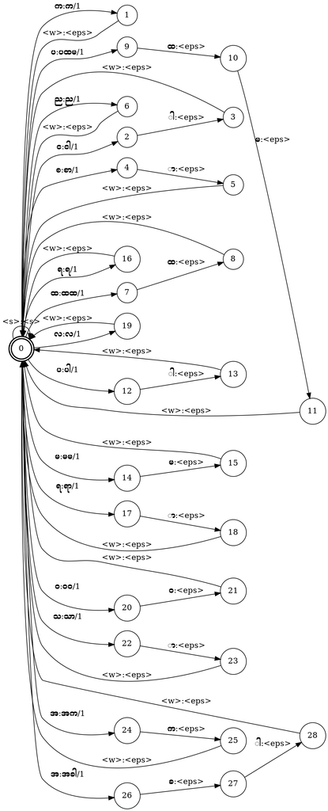

```python
from IPython.display import Image
Image(filename="lexicon.png", width=800)  # Adjust width
```

## Optimization

ဒီနေရာမှာ OpenFST framework ရဲ့ အရေးကြီးတဲ့ command သုံးခုကိုသုံးပြီး model optimization လုပ်သွားပါမယ်။

1. determinize လုပ်တယ် ဆိုတာက non-deterministic FST တွေကို deterministic FST အဖြစ်ပြောင်းလဲတာပါ။ input နဲ့တွဲနေတဲ့ state တစ်ခုချင်းစီကို transition တစ်ခုဖြစ်အောင် ပြောင်းလဲတဲ့အပိုင်းပါ။ မဟုတ်ရင် input symbol တစ်ခုတည်းနဲ့ ချိတ်နေတဲ့ state တစ်ခုတည်းမှာ multiple transition တွေရှိနေတာမို့ network က ဖောင်းပွပြီး ဆုံးဖြတ်ချက်ချရတာမှာ ပိုခက်ခဲလို့ပါ။ Powerset construction algorithm ကိုသုံးပါတယ်။
2. minimize လုပ်တယ် ဆိုတာက မော်ဒယ်တစ်ခုလုံးမှာရှိတဲ့ state အရေအတွက်၊ arc အရေအတွက်တွေကို လျှော့ချတဲ့အပိုင်းပါ။ Hopcroft’s algorithm ကိုသုံးပြီး အလုပ်လုပ်ပုံ တူညီတဲ့ state တွေကို merge လုပ်ပါတယ်။
3. arc တွေကို sorting လုပ်တဲ့ အပိုင်းပါ။

```python
!fstdeterminize lexicon.fst lexicon.det
```

```python
!fstminimize lexicon.det lexicon.min
```

```python
!fstarcsort lexicon.min lexicon.srt
```

Optimization မလုပ်ခင်က .fst ဖိုင်နဲ့ .srt ဖိုင်ရဲ့ filesize ကို နှိုင်းယှဉ်ကြည့်ရင် ကွာတာကို မြင်ရပါလိမ့်မယ်။

```python
!ls -lh lexicon.fst lexicon.srt
```

```
-rw-rw-r-- 1 ye ye 1.1K Jul 16 21:19 lexicon.fst
-rw-rw-r-- 1 ye ye  586 Jul 16 22:18 lexicon.srt
```

srt ဖိုင်ကို text ဖိုင်အဖြစ်ပြောင်းလို့ ရတယ်။

```python
!fstprint --isymbols=./data/char.sym --osymbols=./data/word.sym lexicon.srt > lexicon.srt.txt
```

```python
!cat lexicon.srt.txt
```

```
0	0	<s>	<s>
0	1	က	က	1
0	2	င	ငါ	1
0	3	စ	စာ	1
0	1	ည	ည	1
0	4	ထ	ထထ	1
0	5	ပ	<eps>	1
0	6	မ	မမ	1
0	7	ရ	<eps>	1
0	1	လ	လ	1
0	8	ဝ	ဝဝ	1
0	3	သ	သာ	1
0	9	အ	<eps>	1
0
1	0	<w>	<eps>
2	1	ါ	<eps>
3	1	ာ	<eps>
4	1	ထ	<eps>
5	6	ထ	ပထမ
5	1	ါ	ပါ
6	1	မ	<eps>
7	0	<w>	ရ
7	1	ာ	ရာ
8	1	ဝ	<eps>
9	1	က	အက
9	2	ခ	အခါ
```

```python
!fstdraw --portrait --isymbols=./data/char.sym --osymbols=./data/word.sym ./lexicon.srt  | dot -Tpng -Gdpi=300 > lexicon.srt.png
```

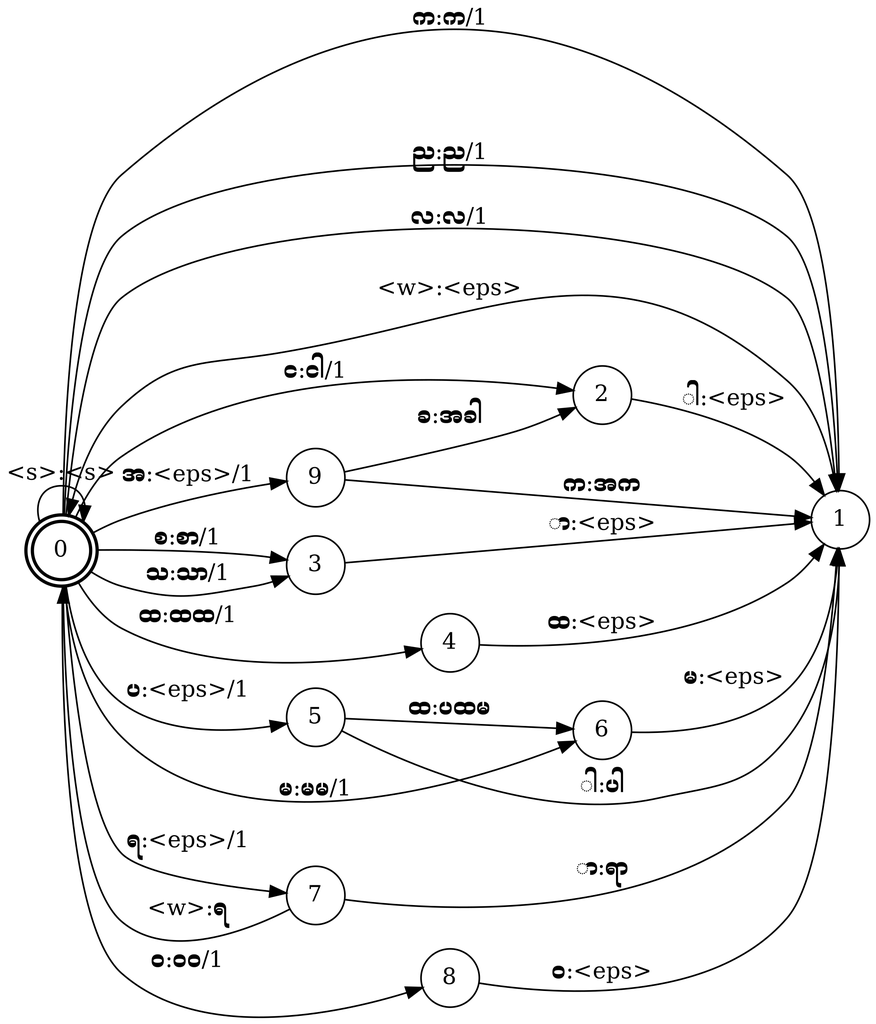

```python
from IPython.display import Image
Image(filename="lexicon.srt.png", width=800)  # Adjust width
```

## Preparation for Decoding

```python
!echo "3 0" > map.txt
```

```python
!cat map.txt
```

```
3 0
```

```python
!fstrelabel --relabel_ipairs=map.txt lexicon.srt lexicon_final.fst
```

ပြန်စစ်ကြည့်ရအောင်

```python
!fstprint --isymbols=./data/char.sym --osymbols=./data/word.sym lexicon_final.fst > lexicon_final.fst.txt
```

```python
!cat ./lexicon_final.fst.txt
```

```
0	0	<s>	<s>
0	1	က	က	1
0	2	င	ငါ	1
0	3	စ	စာ	1
0	1	ည	ည	1
0	4	ထ	ထထ	1
0	5	ပ	<eps>	1
0	6	မ	မမ	1
0	7	ရ	<eps>	1
0	1	လ	လ	1
0	8	ဝ	ဝဝ	1
0	3	သ	သာ	1
0	9	အ	<eps>	1
0
1	0	<eps>	<eps>
2	1	ါ	<eps>
3	1	ာ	<eps>
4	1	ထ	<eps>
5	6	ထ	ပထမ
5	1	ါ	ပါ
6	1	မ	<eps>
7	0	<eps>	ရ
7	1	ာ	ရာ
8	1	ဝ	<eps>
9	1	က	အက
9	2	ခ	အခါ
```

```python
!fstdraw --portrait --isymbols=./data/char.sym --osymbols=./data/word.sym ./lexicon_final.fst  | dot -Tpng -Gdpi=300 > lexicon_final.fst.png
```

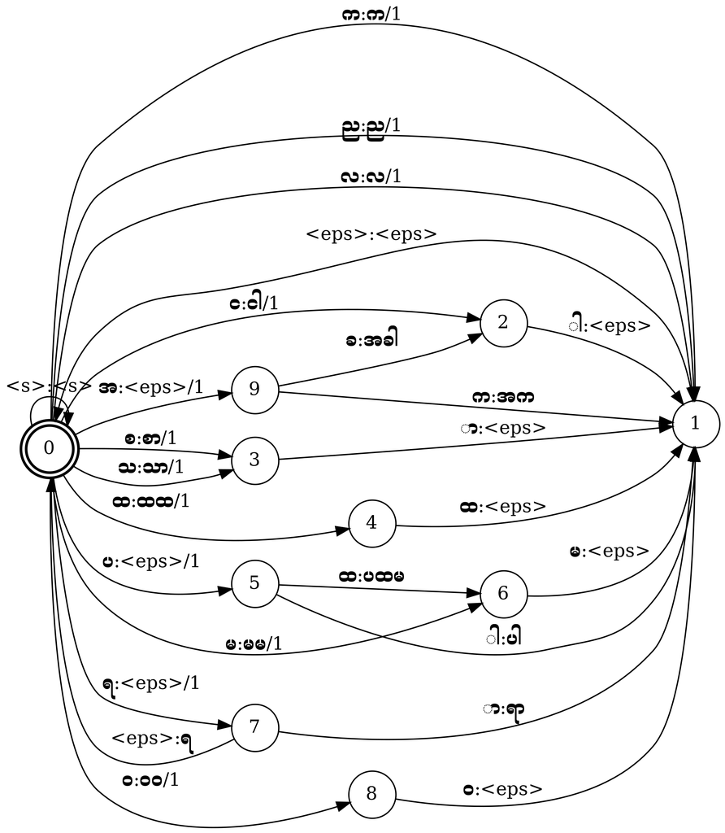

```python
from IPython.display import Image
Image(filename="lexicon_final.fst.png", width=800)  # Adjust width
```

## Configuration File

fst_decoder.py ကို မသုံးခင်မှာ configuration ဖိုင်ကို ကြိုတင်ပြင်ဆင်ထားဖို့ လိုအပ်တယ်။ yaml format ကို သုံးထားတယ်။

```python
!cat config.yaml
```

```
input_format: text
output_format: text
nbest: 1
input_symbols: ./data/char.sym
output_symbols: ./data/word.sym
unknown_symbol: <unk>
terminal_symbol: </s>
models:
  - type: plain
    file: ./lexicon_final.fst
    input_symbols: ./data/char.sym
    output_symbols: ./data/word.sym
    weights: [1.0]
```

## Character Segmentation

Input လုပ်တဲ့အခါမှာ character တစ်လုံးချင်းစီဖြတ်ထားတဲ့ ပုံစံနဲ့ input လုပ်မှာမို့ test data ဖိုင်တွေကို character segmentation လုပ်ဖို့ လိုအပ်တယ်။

```python
!python ./script/char_break.py < ./data/corpus.clean > ./data/corpus.char
```

```python
!cat ./data/corpus.char
```

```
မ မ ဝ ဝ
မ မ ဝ ဝ
ထ ထ က
အ က ပ ထ မ
က ပ ါ က ပ ါ
မ မ ရ ာ
ည ည လ သ ာ သ ာ
ည အ ခ ါ
င ါ စ ာ ရ
မ မ ဝ ဝ
ထ ထ က
```

## Decoding

လက်ရှိ လုပ်ပြတဲ့ ဒီမိုမှာတော့ decoding လုပ်တယ်ဆိုတာက word segmentation လုပ်တာပေါ့။  
fst_decoder.py code ကို လေ့လာချင်သူတွေအတွက် cat နဲ့ ရိုက်ထုတ်ပြမယ်။

```python
!cat fst_decoder.py
```

```
"""
FST Decoder
Written by Ye Kyaw Thu
Last Update: 11 July 2025

Usage:
    python ./fst_decoder.py ./config.yaml --show-id < ./closed_test.txt > closed_test.hyp
    python ./fst_decoder.py ./config.yaml --show-id < ./open_test.txt > open_test.hyp

Reference: https://www.phontron.com/kyfd/
"""

import os
import sys
import yaml
import argparse
import time
from typing import List, Dict, Any
import pywrapfst as fst
import pynini
import tempfile

class ConfigError(Exception):
    pass

class DecoderError(Exception):
    pass

class FSTModel:
    def __init__(self, config, symbol_tables=None):
        """Initialize the FST model with configuration"""
        self.config = config
        self.symbol_tables = symbol_tables or {}
        self.fst = None

    def load(self):
        """Load the FST with explicit symbol tables"""
        try:
            fst_file = self.config.get('file')
            if not fst_file:
```

[output cut: 348 more lines]

```

def main():
    args = parse_args()

    try:
        config = DecoderConfig(args.config, vars(args))
        decoder = Decoder(config)
        success = decoder.decode(sys.stdin, sys.stdout)
        sys.exit(0 if success else 1)
    except Exception as e:
        print(f"FATAL ERROR: {str(e)}", file=sys.stderr)
        sys.exit(1)

if __name__ == "__main__":
    main()
```

## Decoding with Closed Test Data

```python
!time python ./fst_decoder.py ./config.yaml < ./data/corpus.char > ./closed.hyp
```

[output not shown]

```python
!wc closed.hyp
```

```
 11  28 175 closed.hyp
```

```python
!cat closed.hyp
```

```
မမ ဝဝ
မမ ဝဝ
ထထ က
အက ပထမ
က ပါ က ပါ
မမ ရာ
ည ည လ သာ သာ
ည အခါ
ငါ စာ ရ
မမ ဝဝ
ထထ က
```

## Evaluation for Closed-Test Data

ဒီ evaluation script က ဆရာ NICT, Kyoto က Multilingual Machine Translation Lab. မှာ အလုပ်လုပ်ကတည်းက သုံးခဲ့တဲ့ python code ပါ။ အဲဒါကြောင့် run မယ် ဆိုရင် python2.7 နဲ့မှ အဆင်ပြေပါတယ်။ ရေးထားတဲ့ Author က Yue Zhang, University of Oxford ပါ။  
code ကို လေ့လာချင်သူတွေအတွက် cat နဲ့ ရိုက်ထုတ်ပြမယ်။

```python
!cat ./script/evaluate.py
```

```
#****************************************************************
#
# evaluate.py - the evaluation program.
#
# Author: Yue Zhang
#
# Computing lab, University of Oxford. 2006.11
#
#****************************************************************

#================================================================
#
# Import modules.
#
#================================================================

import sys
import os
sys.path.append(os.path.abspath(os.path.join(os.path.dirname(__file__), "..", "libs")))
import getopt

#----------------------------------------------------------------
#
# addTuples - add two tuples element by element.
#
# Inputs:  tuple1 - operand1
#          tuple2 - operand2
#
# Returns: tuple
#
#----------------------------------------------------------------

def addTuples(tuple1, tuple2):
   return tuple([tuple1[i]+tuple2[i] for i in xrange(len(tuple1))])

#----------------------------------------------------------------
#
# addListToList - add the second list to the first list.
#
# Inputs:  list1 - operand1, the one modified list
```

[output cut: 333 more lines]

```

   if ( lReference and not lCandidate ) or ( lCandidate and not lReference ) :
      print "Warning: the reference and the candidate consists of different number of lines!"

   word_precision = float(nTotalCorrectWords) / float(nCandidateWords)
   word_recall = float(nTotalCorrectWords) / float(nReferenceWords)
   tag_precision = float(nTotalCorrectTags) / float(nCandidateWords)
   tag_recall = float(nTotalCorrectTags) / float(nReferenceWords)
   word_fmeasure = (2*word_precision*word_recall)/(word_precision+word_recall)
   if tag_precision+tag_recall==0:
      tag_fmeasure = 0.0
   else:
      tag_fmeasure = (2*tag_precision*tag_recall)/(tag_precision+tag_recall)

   print "Tag precision:", tag_precision
```

```python
!python2.7 ./script/evaluate.py ./closed.hyp ./data/corpus.clean
```

```
Tag precision: 1.0
```

လက်တွေ့ open test နဲ့ decoding လုပ်တဲ့အခါမှာ unknown word တွေပါတဲ့ လိုင်းတွေကို ဆက်လက် word segmentation မလုပ်တာမို့လို့ reference နဲ့ hypothesis ဖိုင်နှစ်ဖိုင်ရဲ့ စာကြောင်းရေ အရေအတွက်မတူတဲ့အခါမျိုးလည်း ဖြစ်တတ်ပါတယ်။ အဲဒီလိုအခြေအနေမှာ တွက်ပေးနိုင်ဖို့အတွက် evaluate_segmentation.py code ကို ရေးခဲ့တယ်။

```python
!python ./script/evaluate_segmentation.py --help
```

```
usage: evaluate_segmentation.py [-h] --ref REF --hyp HYP [--top-k TOP_K]

Boundary-based evaluation for word segmentation (Precision, Recall, F1 +
Token-level Top-K Errors)

options:
  -h, --help     show this help message and exit
  --ref REF      Path to reference (gold) word segmented file
  --hyp HYP      Path to hypothesis file with line ID and segmented output
  --top-k TOP_K  Top-K most frequent token-level segmentation errors to report
                 (default: 10)
```

## Let's Learn evaluate_segmentation.py Code

ဆရာကိုယ်တိုင်ရေးထားတဲ့ evaluate_segmentation.py code ကိုလည်း လေ့လာကြည့်ပါ။

```python
!cat ./script/evaluate_segmentation.py
```

```
"""
Written by Ye Kyaw Thu, LU Lab., Myanmar.
Last updated: 11 July 2025
Usage:
    python ./script/evaluate_segmentation.py --ref data/otest.nopipe.word --hyp open_test.hyp --top-k 10 > open_tesst_score.txt
    python ./script/evaluate_segmentation.py --ref data/ctest10.nopipe.word --hyp closed_test.hyp --top-k 10 > closed_test_score.txt
"""

import argparse
from collections import Counter
import sys

def parse_args():
    parser = argparse.ArgumentParser(
        description="Boundary-based evaluation for word segmentation (Precision, Recall, F1 + Token-level Top-K Errors)"
    )
    parser.add_argument("--ref", type=str, required=True,
                        help="Path to reference (gold) word segmented file")
    parser.add_argument("--hyp", type=str, required=True,
                        help="Path to hypothesis file with line ID and segmented output")
    parser.add_argument("--top-k", type=int, default=10,
                        help="Top-K most frequent token-level segmentation errors to report (default: 10)")
    return parser.parse_args()

def load_reference(ref_path):
    ref_dict = {}
    with open(ref_path, 'r', encoding='utf-8') as f:
        for i, line in enumerate(f):
            tokens = line.strip().split()
            ref_dict[i] = tokens
    return ref_dict

def load_hypothesis(hyp_path):
    hyp_dict = {}
    with open(hyp_path, 'r', encoding='utf-8') as f:
        for line in f:
            if '|||' not in line:
                continue
            idx_str, hyp = line.strip().split('|||', maxsplit=1)
            try:
```

[output cut: 95 more lines]

```
    print("\n=== Word Segmentation Evaluation ===")
    print(f"Total Ref lines: {len(ref_dict)}")
    print(f"Total Hyp lines: {len(hyp_dict)}\n")
    print(f"Precision: {precision:.4f}")
    print(f"Recall:    {recall:.4f}")
    print(f"F1 Score:  {f1:.4f}")

    print(f"\nTop-{args.top_k} Frequent Token-level Segmentation Errors:")
    for i, ((ref_tok, hyp_tok), count) in enumerate(error_counter.most_common(args.top_k), 1):
        print(f"[{i}] Count: {count}")
        print(f"  REF token:     {ref_tok}")
        print(f"  Predicted as:  {hyp_tok}\n")

if __name__ == "__main__":
    main()
```

## Prepare Open Test Data

ဒီ ဒီမိုအတွက် open test ဒေတာကိုတော့ graph ထုတ်ပြီး လေ့လာရ လွယ်ကူအောင် ဆောက်ထားတဲ့ "မမ ဝဝ" ကဗျာ corpus အသေးလေးပေါ်ကိုပဲ အခြေခံပြီး လက်နဲ့ပဲ ပြင်ဆင်ပါမယ်။

```python
!cat ./data/open_test.txt
```

```
မြမြ ဝဝ ထထ က
အက ပထမ
ကပါ ကပါ မြမြ ရာ
ညည လသာသာ
ညအခါ ငါ စာ မ ရ
မြမြ ဝဝ ထထ က
```

### Editing Notes

အထက်မှာ မြင်ရတဲ့အတိုင်း "မမ" နေရာမှာ "မြမြ" နဲ့ အစားထိုးထားတယ်။  
ပြီးတော့ "မြမြ ဝဝ" နဲ့ "ထထ က" ဆိုတဲ့ စာကြောင်းကို နှစ်ကြောင်းခွဲမထားပဲ ပေါင်းရေးပြီး စာကြောင်းတစ်ကြောင်း အဖြစ်ဖြစ် ထားထားတာမျိုးတွေလည်း ရှိတယ်။  
"ငါ စာ မ ရ" ဆိုပြီးတော့ "စာရ" ဆိုတဲ့ စာလုံးရဲ့ အကြားမှာလည်း "မ" ထည့်တာမျိုး editing လုပ်ထားပါတယ်။  
အဲဒါမှလည်း open test ရဲ့ nature အတိုင်း မော်ဒယ်ဆောက်တုန်းက မပါတဲ့ word တွေ ပါလာမှာမျိုးဖြစ်လို့ simulation လုပ်ယူထားတာပါ။

## Character Segmentation

Character တစ်လုံးချင်းစီ ဖြစ်သွားပြီးမှ input လုပ်ပြီး စာလုံးဖြတ်ပေး မပေး (သို့) စာလုံးအဖြစ် တွဲပေး မပေး ကြည့်ချင်တာမို့ ...

```python
!cat ./data/open_test.txt | python ./script/char_break.py > ./data/open_test.char
```

### Check Character Segmented Output File

Character ဖြတ်ပြီးထွက်လာတဲ့ output ဖိုင်ကို ဝင်စစ်ဆေးကြည့်ရအောင်။

```python
!cat ./data/open_test.char
```

```
မ ြ မ ြ ဝ ဝ ထ ထ က
အ က ပ ထ မ
က ပ ါ က ပ ါ မ ြ မ ြ ရ ာ
ည ည လ သ ာ သ ာ
ည အ ခ ါ င ါ စ ာ မ ရ
မ ြ မ ြ ဝ ဝ ထ ထ က
```

## Decoding with Open Test Data

တနည်းအားဖြင့် open test data ကိုသုံးပြီး word segmentation လုပ်ခိုင်းတာပါပဲ။  
ဆောက်ထားတာက word segmentation FST မို့လို့ ပါ။

ဒီတခါတော့ မော်ဒယ်က ထွက်လာတဲ့ စာကြောင်းတွေက input file ရဲ့ စာကြောင်းအရေအတွက်အတိုင်း ဟုတ်ချင်မှ ဟုတ်မှာမို့ --show-id ဆိုတဲ့ option ကိုသုံးပြီးတော့ decode လုပ်ပါမယ်။

```python
!time python ./fst_decoder.py ./config.yaml  --show-id < ./data/open_test.char > ./open.hyp
```

[output not shown]

## Let's Check Segmented Open Data

FST model ကနေ ဖြတ်ပြီးထွက်လာတဲ့ output ဖိုင်ကို လေ့လာကြည့်ရင် အောက်ပါအတိုင်း တွေ့ရပါလိမ့်မယ်။

```python
!cat ./open.hyp
```

```
1|||အက ပထမ
3|||ည ည လ သာ သာ
```

Input ဖိုင် (character segmentation မဖြတ်ရသေးခင်က) နဲ့ ပြန်နှိုင်းယှဉ်ကြည့် ရအောင်...

```python
!cat ./data/open_test.txt
```

```
မြမြ ဝဝ ထထ က
အက ပထမ
ကပါ ကပါ မြမြ ရာ
ညည လသာသာ
ညအခါ ငါ စာ မ ရ
မြမြ ဝဝ ထထ က
```

## Evaluation

ဒီတခါတော့ reference ဖိုင်နဲ့ hypothesis က လိုင်းအရေအတွက် မတူညီတဲ့ကြားထဲကနေပဲ evaluation အကြမ်းလုပ်ကြည့်ချင်တာမို့လို့ evaluate_segmentation.py code ကို သုံးပါမယ်။

```python
!python ./script/evaluate_segmentation.py --ref ./data/open_test.txt --hyp ./open.hyp
```

```
=== Word Segmentation Evaluation ===
Total Ref lines: 6
Total Hyp lines: 2

Precision: 0.4000
Recall:    0.1333
F1 Score:  0.2000

Top-10 Frequent Token-level Segmentation Errors:
```

## Summary

ဒီ တခေါက်က FST ရဲ့ အလုပ်လုပ်ပုံကို မြင်စေချင်လို့ ဆရာဦးတင်မိုးရဲ့ "မမ ဝဝ" ကလေးကဗျာလေးကိုပဲ corpus အသေးလေးဆောက်ခဲ့ပြီး Lexicon FST ကို visualization လုပ်ပြခဲ့တာဖြစ်ပါတယ်။ Corpus size က တအားသေးတော့ optimization မလုပ်ခင်နဲ့ လုပ်ပြီးသားမှာ filesize အနေနဲ့ အရမ်းကွာခြားသွားတာမျိုး မဟုတ်ပေမဲ့ graph အပြောင်းအလဲတွေကိုတော့ အတိုင်းအတာတခုထိ မြင်နိုင်တာမို့ အကျိုးရှိပါလိမ့်မယ်။